# **Loan Default Prediction**

## **Additional Optimization**

## **Boosting Models**

Let's now look at the other kind of Ensemble technique knowns as Boosting

### **XGBoost**

- XGBoost stands for Extreme Gradient Boosting.
- XGBoost is a tree-based ensemble machine learning technique that improves prediction power and performance by improvising on the Gradient Boosting framework and incorporating reliable approximation algorithms. It is widely utilized and routinely appears at the top of competition leader boards in data science.

```python
# Import necessary libraries
from sklearn.ensemble import AdaBoostClassifier, GradientBoostingClassifier
from xgboost import XGBClassifier
from sklearn import metrics

# Define classifiers
adaboost_original = AdaBoostClassifier(random_state=1)
adaboost_weighted = AdaBoostClassifier(random_state=1)
gradient_boost_original = GradientBoostingClassifier(random_state=1)
gradient_boost_weighted = GradientBoostingClassifier(random_state=1)
xgboost_original = XGBClassifier(random_state=1)
xgboost_weighted = XGBClassifier(random_state=1)

# List of models
models = [adaboost_original, adaboost_weighted, gradient_boost_original, gradient_boost_weighted, xgboost_original, xgboost_weighted]

# Defining empty lists to add F1 scores
f1_train = []
f1_test = []

# Looping through all the models to get the F1 scores
for model in models:
    # Fit the model
    model.fit(X_train, y_train)

    # F1 score
    train_f1 = metrics.f1_score(y_train, model.predict(X_train))
    test_f1 = metrics.f1_score(y_test, model.predict(X_test))
    f1_train.append(train_f1)
    f1_test.append(test_f1)

# Create a table comparing F1 scores
f1_comparison_frame = pd.DataFrame({
    'Model': ['AdaBoost (Original)', 'AdaBoost (Weighted)', 'Gradient Boost (Original)', 'Gradient Boost (Weighted)',
              'XGBoost (Original)', 'XGBoost (Weighted)'],
    'Train_F1': f1_train,
    'Test_F1': f1_test
})

# Display the F1 scores comparison table
f1_comparison_frame
```

|  | Model | Train_F1 | Test_F1 |
| --- | --- | --- | --- |
| 0 | AdaBoost (Original) | 0.541291 | 0.529126 |
| 1 | AdaBoost (Weighted) | 0.541291 | 0.529126 |
| 2 | Gradient Boost (Original) | 0.687324 | 0.582474 |
| 3 | Gradient Boost (Weighted) | 0.687324 | 0.582474 |
| 4 | XGBoost (Original) | 0.995652 | 0.769231 |
| 5 | XGBoost (Weighted) | 0.995652 | 0.769231 |

**Observations**

- XGBoost (Weighted) offers the best results with 0.995652 F1 score on the traning set and 0.769231 F1 score on the test set.

```
              precision    recall  f1-score   support

           0       0.91      0.99      0.95       927
           1       0.94      0.65      0.77       265

    accuracy                           0.91      1192
   macro avg       0.92      0.82      0.86      1192
weighted avg       0.91      0.91      0.91      1192
```

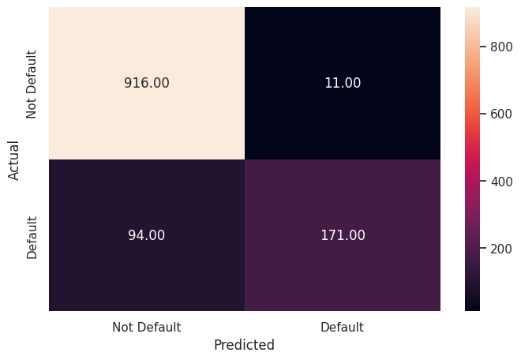

```python
# Specify the class weights
class_weights = {0: 0.22, 1: 0.78}

# Create XGBoost Classifier
xgb = XGBClassifier(random_state=2, eval_metric='logloss', scale_pos_weight=class_weights[1])

# Fitting the model on the training data
xgb.fit(X_train, y_train)

# Model Performance on the test data
y_pred_xgb = xgb.predict(X_test)

# Calculate and print metrics
accuracy = accuracy_score(y_test, y_pred_xgb)
conf_matrix = confusion_matrix(y_test, y_pred_xgb)
class_report = classification_report(y_test, y_pred_xgb)

# Model Performance on the test data
y_pred_xgb = xgb.predict(X_test)

# Evaluate performance using your metrics_score function
metrics_score(y_test, y_pred_xgb)
```

**Observations:**

- The Tuned XGBoost model is giving a 95% f1 score for category 0 and 77% f1 score for category 1 on the test dataset.

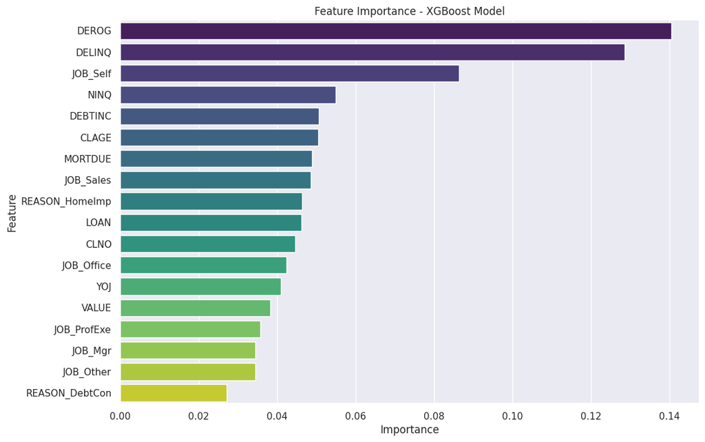

```python
import matplotlib.pyplot as plt
import seaborn as sns

# Get feature importances from the XGBoost model
feature_importance = xgb.feature_importances_

# Create a DataFrame to store feature names and their importance
feature_importance_df = pd.DataFrame({'Feature': X_train.columns, 'Importance': feature_importance})

# Sort the DataFrame based on importance
feature_importance_df = feature_importance_df.sort_values(by='Importance', ascending=False)

# Plot the feature importances
plt.figure(figsize=(12, 8))
sns.barplot(x='Importance', y='Feature', data=feature_importance_df, palette='viridis')
plt.title('Feature Importance - XGBoost Model')
plt.show()
```

**Observations**

- DEROG and DELINQ Dominance: The features DEROG (Derogatory Public Records) and DELINQ (Number of Delinquencies) have the highest importance scores, indicating that they play a crucial role in predicting loan eligibility. Borrowers with a history of derogatory records or delinquencies are likely to have a significant impact on the model's decision.
- Job Type Significance: JOB_Self, JOB_Sales, JOB_Office, JOB_ProfExe, JOB_Mgr, and JOB_Other are features related to the borrower's job type. JOB_Self appears to be the most influential among them, suggesting that self-employed individuals may have a distinct impact on the model.
- Debt-related Features: DEBTINC (Debt-to-Income Ratio) and NINQ (Number of Recent Credit Inquiries) also contribute significantly to the model's decision. High debt-to-income ratios and recent credit inquiries may be indicative of financial strain.
- Loan-related Features: LOAN (Loan Amount) and REASON_HomeImp (Reason for Loan - Home Improvement) have noteworthy importance scores. The loan amount and the purpose of the loan (home improvement) seem to influence the model's predictions.
- Property Value and Age of Oldest Trade Line: VALUE (Estimated Property Value) and CLAGE (Age of Oldest Trade Line in Months) contribute moderately to the model. These factors may reflect the borrower's financial stability and credit history.
- Other Job Types and Loan Reasons: Other job types (JOB_Other) and the reason for the loan being debt consolidation (REASON_DebtCon) also have some impact, although their importance scores are relatively lower.

```python
!pip install joblib

from xgboost import XGBClassifier
import joblib

# Specify the class weights
class_weights = {0: 0.22, 1: 0.78}

# Create XGBoost Classifier
xgb = XGBClassifier(random_state=2, eval_metric='logloss', scale_pos_weight=class_weights[1])

# Fitting the model on the training data
xgb.fit(X_train, y_train)

# Save the model to a file
joblib.dump(xgb, 'xgboost_model.joblib')
```

```
['xgboost_model.joblib']
```

```python
import pandas as pd
from xgboost import XGBClassifier
import joblib

# Later, you can load the model like this
loaded_model = joblib.load('xgboost_model.joblib')

# Load input data from CSV
input_data = pd.read_csv('data.csv')

# Display loaded input data
print("Loaded Input Data:")
print(input_data)

# Make predictions using the loaded model
prediction = loaded_model.predict(input_data)

# Display the prediction
print("Prediction: ", prediction[0])
```

```
Loaded Input Data:
    LOAN  MORTDUE   VALUE  YOJ  DEROG  DELINQ  CLAGE  NINQ  CLNO  DEBTINC  \
0  10000    20000  300000   10      0       0    121     0    12       20

   REASON_DebtCon  REASON_HomeImp  JOB_Mgr  JOB_Office  JOB_Other  \
0               0               1        1           0          0

   JOB_ProfExe  JOB_Sales  JOB_Self
0            0          0         0
Prediction:  0
```

Now that we know which clients we are going to accept, let's create a model to determine how much money we can lend to them.

```python
# Copying data to another variable to avoid any changes to original data
df=df_imputed.copy()
df
```

|  | LOAN | MORTDUE | VALUE | YOJ | DEROG | DELINQ | CLAGE | NINQ | CLNO | DEBTINC | REASON_DebtCon | REASON_HomeImp | JOB_Mgr | JOB_Office | JOB_Other | JOB_ProfExe | JOB_Sales | JOB_Self | BAD |
| --- | --- | --- | --- | --- | --- | --- | --- | --- | --- | --- | --- | --- | --- | --- | --- | --- | --- | --- | --- |
| 0 | 1100.0 | 25860.0 | 39025.0 | 10.5 | 0.0 | 0.0 | 94.366667 | 1.0 | 9.0 | 23.314070 | 0.0 | 1.0 | 0.0 | 0.0 | 1.0 | 0.0 | 0.0 | 0.0 | 1 |
| 1 | 1300.0 | 70053.0 | 68400.0 | 7.0 | 0.0 | 2.0 | 121.833333 | 0.0 | 14.0 | 39.704157 | 0.0 | 1.0 | 0.0 | 0.0 | 1.0 | 0.0 | 0.0 | 0.0 | 1 |
| 2 | 1500.0 | 13500.0 | 16700.0 | 4.0 | 0.0 | 0.0 | 149.466667 | 1.0 | 10.0 | 36.196050 | 0.0 | 1.0 | 0.0 | 0.0 | 1.0 | 0.0 | 0.0 | 0.0 | 1 |
| 3 | 1500.0 | 48080.6 | 58891.4 | 6.8 | 0.6 | 0.8 | 110.973073 | 0.6 | 12.6 | 27.796030 | 0.0 | 0.0 | 0.0 | 0.0 | 0.0 | 0.0 | 0.0 | 0.0 | 1 |
| 4 | 1700.0 | 97800.0 | 112000.0 | 3.0 | 0.0 | 0.0 | 93.333333 | 0.0 | 14.0 | 34.370509 | 0.0 | 1.0 | 0.0 | 1.0 | 0.0 | 0.0 | 0.0 | 0.0 | 0 |
| ... | ... | ... | ... | ... | ... | ... | ... | ... | ... | ... | ... | ... | ... | ... | ... | ... | ... | ... | ... |
| 5955 | 88900.0 | 57264.0 | 90185.0 | 16.0 | 0.0 | 0.0 | 221.808718 | 0.0 | 16.0 | 36.112347 | 1.0 | 0.0 | 0.0 | 0.0 | 1.0 | 0.0 | 0.0 | 0.0 | 0 |
| 5956 | 89000.0 | 54576.0 | 92937.0 | 16.0 | 0.0 | 0.0 | 208.692070 | 0.0 | 15.0 | 35.859971 | 1.0 | 0.0 | 0.0 | 0.0 | 1.0 | 0.0 | 0.0 | 0.0 | 0 |
| 5957 | 89200.0 | 54045.0 | 92924.0 | 15.0 | 0.0 | 0.0 | 212.279697 | 0.0 | 15.0 | 35.556590 | 1.0 | 0.0 | 0.0 | 0.0 | 1.0 | 0.0 | 0.0 | 0.0 | 0 |
| 5958 | 89800.0 | 50370.0 | 91861.0 | 14.0 | 0.0 | 0.0 | 213.892709 | 0.0 | 16.0 | 34.340882 | 1.0 | 0.0 | 0.0 | 0.0 | 1.0 | 0.0 | 0.0 | 0.0 | 0 |
| 5959 | 89900.0 | 48811.0 | 88934.0 | 15.0 | 0.0 | 0.0 | 219.601002 | 0.0 | 16.0 | 34.571519 | 1.0 | 0.0 | 0.0 | 0.0 | 1.0 | 0.0 | 0.0 | 0.0 | 0 |

5960 rows × 19 columns

```python
!pip install scikit-learn xgboost
```

```python
import pandas as pd
from sklearn.model_selection import train_test_split
from sklearn.tree import DecisionTreeRegressor
from sklearn.ensemble import RandomForestRegressor, AdaBoostRegressor, GradientBoostingRegressor
from xgboost import XGBRegressor
from sklearn.metrics import mean_squared_error, mean_absolute_error, r2_score
from math import sqrt

# Assuming your dataset is stored in a variable named 'df'
# Separate features (X) and target variable (y)
X = df.drop(['LOAN', 'BAD'], axis=1)
y = df['LOAN']

# Split the data into training and testing sets
X_train, X_test, y_train, y_test = train_test_split(X, y, test_size=0.2, random_state=42)

# Create and train models
models = {
    'Decision Tree': DecisionTreeRegressor(random_state=2),
    'Random Forest': RandomForestRegressor(random_state=2),
    'AdaBoost': AdaBoostRegressor(random_state=2),
    'Gradient Boosting': GradientBoostingRegressor(random_state=2),
    'XGBoost': XGBRegressor(random_state=2)
}

results = {}

for model_name, model in models.items():
    # Train the model
    model.fit(X_train, y_train)

    # Predict on the test set
    y_pred = model.predict(X_test)

    # Evaluate the model
    rmse = sqrt(mean_squared_error(y_test, y_pred))
    mae = mean_absolute_error(y_test, y_pred)
    r_squared = r2_score(y_test, y_pred)

    # Calculate Mean Absolute Percentage Error (MAPE)
    mape = 100 * (abs((y_test - y_pred) / y_test)).mean()

    # Calculate Adjusted R-squared
    n = len(y_test)
    p = X_test.shape[1]  # Number of features
    adjusted_r_squared = 1 - ((1 - r_squared) * (n - 1) / (n - p - 1))

    results[model_name] = {'RMSE': rmse, 'MAE': mae, 'MAPE': mape, 'R-squared': r_squared, 'Adjusted R-squared': adjusted_r_squared}

# Display the results
for model_name, metrics in results.items():
    print(f"{model_name} - RMSE: {metrics['RMSE']:.2f}, MAE: {metrics['MAE']:.2f}, MAPE: {metrics['MAPE']:.2f}%, R-squared: {metrics['R-squared']:.2f}, Adjusted R-squared: {metrics['Adjusted R-squared']:.2f}")
```

```
Decision Tree - RMSE: 7103.39, MAE: 3843.20, MAPE: 31.39%, R-squared: 0.65, Adjusted R-squared: 0.64
Random Forest - RMSE: 5169.32, MAE: 3051.24, MAPE: 25.49%, R-squared: 0.81, Adjusted R-squared: 0.81
AdaBoost - RMSE: 10110.60, MAE: 7994.55, MAPE: 69.86%, R-squared: 0.29, Adjusted R-squared: 0.28
Gradient Boosting - RMSE: 8407.95, MAE: 5641.56, MAPE: 42.46%, R-squared: 0.51, Adjusted R-squared: 0.50
XGBoost - RMSE: 5387.41, MAE: 3460.15, MAPE: 28.85%, R-squared: 0.80, Adjusted R-squared: 0.79
```

**Observations:**